# Session 11 Review and Q & A

[**CCMVI2085U Machine Learning for Predictive Analytics in Business @ CBS ISUP 2020**](https://kursuskatalog.cbs.dk/2019-2020/KAN-CCMVI2085U.aspx?lang=en-GB)

Course coordinator: [Bowei Chen](https://boweichen.github.io/) | Email: bc.acc@cbs.dk

# Table of Contents

## Revisit the expected learning outcomes

By the end of this course students will be able to:

1. Have a good understanding of the fundamental issues and challenges of machine learning
2. Appropriately choose and appraise machine learning algorithms for predictive analytics in business
3. Effectively use Python to process, summarize and visualize business data
4. Effectively use Python to implement machine learning algorithms to solve business problems

## Theory

### What is machine learning?

A computer program is said to **learn** from experience $E$ with respect to some class of tasks $T$ and performance measure $P$, if its performance at tasks in $T$, as measured by $P$, improves with experience $E$. -- Tom Mitchell

Let's look at the fashion minst recognition example:

- Task $T$: recognizing and classifying fashion products within images
- Performance measure $P$: percent of fashion products correctly classified
- Training experience $E$: a database of fashion products with given classifications

**Machine learning** is the study of computer algorithms that improve automatically through experience. It is seen as a subset of artificial intelligence. Machine learning algorithms build a mathematical model based on sample data, known as "training data", in order to make predictions or decisions without being explicitly programmed to do so. -- Wikipedia

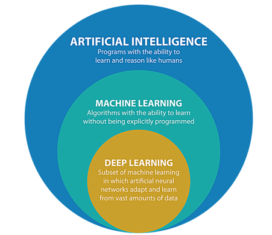

Fig source: https://blog.digitalogy.co/

### Different tasks/problems in supervised learning and unsupervised learning

[figure not shown]

### Machine learning algorithms studied in this course

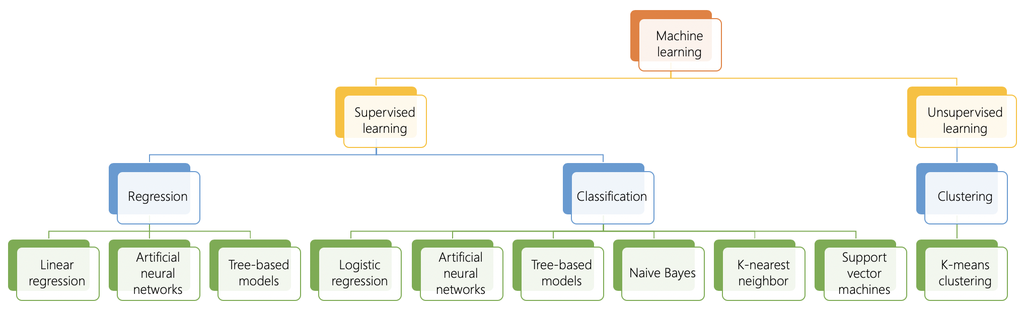

**Linear regression**

The average of the response is the linear combination of the weights and the input features. Note that the term linear here means the response variable linear in weights! Therefore, polynomial regression is regarded as the generalized linear model.

- Models
  - Simple linear regression
  - Multiple linear regression
  - Polynomial regression
  - Lasso regression
  - Ridge regression
- Tasks
  - Regression
- Pros
  - Simple to understand
  - Good interpretability
- Cons
  - Oversimplify or fail in non-linear problems or high dimensional data
  - Sensitive to outliers and noises

**Logistic regression**

- Models
  - Two-class logistic regression
  - Multi-class logistic regression (one-vs-rest)
- Tasks
  - Classification
- Pros
  - Simple to understand
  - Good interpretability
  - Computational inexpensive
  - Perform well when data is linearly separable
- Cons
  - Oversimplify or fail in non-linear problems or high dimensional data

**Artificial neural networks**

- Models
  - Multi-layer perceptron (MLP)
- Tasks
  - Regression
  - Classification
- Pros
  - Perform well in non-linear problems
  - Perform well in high dimensional data
  - Perform well in large-scale data
- Cons
  - Computationally expensive
  - Prone to overfit
  - Black-box model (poor interpretability)

**Naive Bayes**

- Models
  - Gaussian naive Bayes
  - Categorical naive Bayes
  - Mixture naive Bayes
- Tasks
  - Classification
- Pros
  - Simple to understand
  - Good interpretability
  - Computational inexpensive
  - Perform relatively well with small data
- Cons
  - Sensitive to the input features and label distributions
  - Poorly perform with high dimensional and large-scale data

**K-nearest neighbors**

- Models
  - K-nearest neighbors
- Tasks
  - Classification
- Pros
  - Simple to understand
  - Insensitive to outliers
  - No assumptions about data
  - Perform relatively well with small data
- Cons
  - Computational expensive
  - Perform well with numerical variables rather than nominal variables

**Decision trees**

- Models
  - CART (gini impurity)
  - ID3 (information gain based on entropy)
  - C4.5 (information gain ratio based on entropy)
- Tasks
  - Regression
  - Classification
- Pros
  - Simple to understand
  - Insensitive to outliers
  - Good interpretability (white-box model)
  - No assumptions about data
  - Perform well with small data
  - Perform well with high dimensional data
  - Perform well in non-linear problems
- Cons
  - Prone to overfitting

**Tree-based ensemble learning**

- Models
  - AdaBoost
  - Random forest
  - Gradient boosted decision tree (GDBT)
- Tasks
  - Regression
  - Classification
- Pros
  - Simple to understand
  - Insensitive to outliers
  - No assumptions about data
  - Perform well with small data
  - Perform well with high dimensional data
  - Perform well in non-linear problems
- Cons
  - GDBT is computational expensive
  - Instable outputs or training process
  - Prone to overfitting

There is no "best" algorithm for all scenarios and datasets. Generally speaking,

- For small data which is linear separable, logistic regression and support-vector machines perform well. If you wish to estimate probabilities, logistic regression is the choice
- For small data which is not linear separable, support-vector machines and decision trees perform well
- For large-scale high dimensional data, neural networks and tree-based ensemble methods perform well. Random forest can be implemented in parallel, therefore, its training can be faster than neural networks. However, neural networks, particularly deep neural networks has a high potential in performance for larger data and can provide end-to-end solution.

### Cost/loss function

- Mean squared errors for regression
- Cross entropy for classification
- Data loss + structural loss (e.g., ridge regression, lasso regression, SVM soft margin classifier)

### Model evaluation

- Regression
  - Mean squared errors
  - Mean absolute error
  - R squared
- Classification
  - Accuracy
  - Precision (e.g., recommender systems, information retrieval)
  - Recall (e.g., fraud detection)
  - F1 measure
  - AUC/ROC (for two-class classification)

## Practice

- Programming language: Python 3
- IDE: Jupyter Notebook
- Python basic syntax + libraries (numpy, pandas, matplotlib, seaborn, sklearn)

### Python basic syntax

- Data collection
  - List
  - Tuple
  - Set
  - Dictionary
- Control flow
  - if, elif, else
  - for loops
  - while loops
- Functions

### Python libraries

#### Data manipulation

- `NumPy` -> ndarray
- `pandas` -> data frame

#### Data visualization

- `matplotlib` -> pyplot
- `seaborn`

#### Machine learning

Linear regression

`sklearn.linear_model`

- `LinearRegression`: https://scikit-learn.org/stable/modules/generated/sklearn.linear_model.LinearRegression.html
- `Ridge`: https://scikit-learn.org/stable/modules/generated/sklearn.linear_model.Ridge.html
- `Lasso`: https://scikit-learn.org/stable/modules/generated/sklearn.linear_model.Lasso.html

Logistic regression

`sklearn.linear_model`

- `LogisticRegression`: https://scikit-learn.org/stable/modules/generated/sklearn.linear_model.LogisticRegression.html

Neural networks

`sklearn.neural_network`

- `MLPClassifier`: https://scikit-learn.org/stable/modules/generated/sklearn.neural_network.MLPClassifier.html
- `MLPRegressor`: https://scikit-learn.org/stable/modules/generated/sklearn.neural_network.MLPRegressor.html

Naive Bayes

`sklearn.naive_bayes`

- `GaussianNB`: https://scikit-learn.org/stable/modules/generated/sklearn.naive_bayes.GaussianNB.html
- `CategoricalNB`: https://scikit-learn.org/stable/modules/generated/sklearn.naive_bayes.CategoricalNB.html
- `mixed-naive-bayes`: https://pypi.org/project/mixed-naive-bayes/

K-nearest neighbors

`sklearn.neighbors`

- `KNeighborsClassifier`: https://scikit-learn.org/stable/modules/generated/sklearn.neighbors.KNeighborsClassifier.html

Tree-based models

`sklearn.tree`

- `DecisionTreeClassifier`: https://scikit-learn.org/stable/modules/generated/sklearn.tree.DecisionTreeClassifier.html
- `DecisionTreeRegressor`: https://scikit-learn.org/stable/modules/generated/sklearn.tree.DecisionTreeRegressor.html

`sklearn.ensemble`

- `RandomForestClassifier`: https://scikit-learn.org/stable/modules/generated/sklearn.ensemble.RandomForestClassifier.html
- `RandomForestRegressor`: https://scikit-learn.org/stable/modules/generated/sklearn.ensemble.RandomForestRegressor.html
- `AdaBoostClassifier`: https://scikit-learn.org/stable/modules/generated/sklearn.ensemble.AdaBoostClassifier.html
- `AdaBoostRegressor`: https://scikit-learn.org/stable/modules/generated/sklearn.ensemble.AdaBoostRegressor.html
- `GradientBoostingClassifier`: https://scikit-learn.org/stable/modules/generated/sklearn.ensemble.GradientBoostingClassifier.html
- `GradientBoostingRegressor`: https://scikit-learn.org/stable/modules/generated/sklearn.ensemble.GradientBoostingRegressor.html

Support-vector machines

`sklearn.svm`

- `LinearSVC`: https://scikit-learn.org/stable/modules/generated/sklearn.svm.LinearSVC.html
- `NuSVC`: https://scikit-learn.org/stable/modules/generated/sklearn.svm.NuSVC.html
- `SVC`: https://scikit-learn.org/stable/modules/generated/sklearn.svm.SVC.html

K-means clustering

`sklearn.cluster`

- `KMeans`: https://scikit-learn.org/stable/modules/generated/sklearn.cluster.KMeans.html

Data preprocessing

`sklearn.preprocessing`

- `OneHotEncoder`: https://scikit-learn.org/stable/modules/generated/sklearn.preprocessing.OneHotEncoder.html
- `LabelEncoder`: https://scikit-learn.org/stable/modules/generated/sklearn.preprocessing.LabelEncoder.html
- `StandardScaler`: https://scikit-learn.org/stable/modules/generated/sklearn.preprocessing.StandardScaler.html
- `minmax_scale`: https://scikit-learn.org/stable/modules/generated/sklearn.preprocessing.minmax_scale.html
- `PolynomialFeatures`: https://scikit-learn.org/stable/modules/generated/sklearn.preprocessing.PolynomialFeatures.html

Model evaluation metrics

`sklearn.metrics`:

- `confusion_matrix`: https://scikit-learn.org/stable/modules/generated/sklearn.metrics.confusion_matrix.html
- `accuracy_score`: https://scikit-learn.org/stable/modules/generated/sklearn.metrics.accuracy_score.html
- `roc_curve`: https://scikit-learn.org/stable/modules/generated/sklearn.metrics.roc_curve.html
- `auc`: https://scikit-learn.org/stable/modules/generated/sklearn.metrics.auc.html
- `classification_report`: https://scikit-learn.org/stable/modules/generated/sklearn.metrics.classification_report.html

## References

Recommended textbooks for this course:

- C.Bishop. **Pattern Recognition and Machine Learning**, Springer 2007.
- K.Murphy. **Machine Learning: A Probabilistic Perspective**, MIT Press 2012.
- M.Deisenroth, A.Faisal, and C.Ong. **Mathematics for Machine Learning**, Cambridge University Press, 2020.
- S.Ross. **A First Course in Probability**. Pearson, 9th Edition, 2014.
- W.McKinney. **Python for Data Analysis: Data Wrangling with Pandas, NumPy, and IPython**, O'Reilly, 2012

Recommended chapters from these textbooks are:

- Session 2: Murphy Chapter 2 & Deisenroth Chapters 2-6 & Ross. Chapters 1-8
- Session 3: McKinney Chapters 4 & 5
- Session 4: Murphy Chapter 7
- Session 5: Murphy Chapter 8
- Session 6: Bishop Chapter 5
- Session 7: Murphy Chapter 16
- Session 8: Murphy Chapters 1 & 3
- Session 9: Murphy Chapter 14
- Session 10: Bishop Chapter 9

## CBS course evaluation

All course coordinators and/or teachers at CBS are asked to allocate time in the last class for evaluation. This means that the teacher should set aside at least 20 minutes for evaluation.

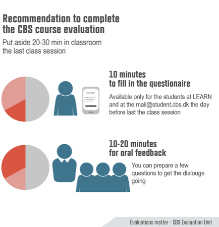